# Regularization_Redkokosh

Redkokosh Kirill

5/23/2022

1. Generate a data set with p = 20 features, n = 1000 observations, and an associated quantitative response vector generated according to the model $Y=X\beta+\epsilon$:

```r
mean <- rnorm(20, mean = 0, sd = 0.9)
mean
```

```
##  [1]  0.41358164 -1.13719842 -0.19349654  1.41127956 -0.06560544  1.72605590
##  [7]  0.88702836 -1.20940657  0.25342042  1.84416035  0.81885257 -0.59434115
## [13]  0.50205901 -1.98552334 -0.20756171 -0.28643982 -0.57487747 -0.33746286
## [19]  0.03012387  0.68187015
```

```r
data <- data.frame(rnorm(n = 1000, mean = mean[1], sd = 1))
for (i in 2:20){
  data <- cbind(data, rnorm(n = 1000, mean = mean[i], sd = 1))
}
beta <- rnorm(20, mean = 0, sd = 1)
min10 <- quantile(beta, probs = 0.1)
max5 <- quantile(beta, probs = 0.95)
beta[beta > max5 | beta < min10] <- 0
Xbeta <- as.matrix(data, 1000, 20)%*%beta + rnorm(n = 1000, mean = mean, sd = 0.1)
data <- cbind(data, Xbeta)
data <- setNames(data, c(paste0('X', 1:20), 'Y'))
head(data)
```

```
##           X1         X2         X3         X4          X5         X6         X7
## 1  0.9467584 -1.7778686 -0.6778483  0.2705028  0.09869174  2.2195134  0.4967843
## 2  0.8232007 -0.3506659 -1.6130528 -0.2539542  1.00749035  2.0842301  1.0113553
## 3  0.5226139 -0.9299977 -1.1205157  2.5124702  0.75980903  2.6951043 -0.1323542
## 4 -1.0927408 -1.5751759  0.4645349  2.4311112  0.16866573 -0.7357623  0.8991572
## 5  1.2223753 -0.5150124 -0.6122846  0.4252250 -0.52082350  1.7296839 -0.4204209
## 6  0.9371332 -1.1493242 -1.0743364  1.1506269  0.56362542  1.0934402  0.3071871
##           X8          X9      X10       X11        X12         X13        X14
## 1 -0.5496808  1.46105132 3.053313 1.3328154 -0.5383216 -0.02688778 -3.4569596
## 2 -0.7451118 -0.56850265 3.072749 0.3473614 -1.4707270  2.76269661 -2.7897657
## 3 -1.7450923  0.05201787 3.189558 1.4640237  0.6599654  2.24442142 -1.2301644
## 4 -0.6932330  1.67686879 2.285970 2.3264521 -1.1228074  0.55239288 -2.3075389
## 5 -3.0746982  1.03772707 1.630241 0.7987820  0.8660704 -2.38367186 -0.9558585
## 6 -2.8226314 -0.79127329 1.933368 0.5309139 -2.0533742  0.62613444 -1.5430765
##          X15        X16        X17        X18        X19        X20          Y
## 1 -1.0535577 -1.1254537 -0.4930792  0.8948037  0.9068306 -0.5106161  1.9831916
## 2 -0.6735942 -0.3830233 -0.7111363  1.1464328  1.7004209  1.1660817  4.4414923
## 3 -0.6209307  1.9673149 -0.1786846  1.0167925 -0.8310651  1.0720771  3.4492910
## 4  0.3576679 -1.4881001 -2.1916783 -0.6520100 -1.4452322 -0.2834377 -2.3075776
## 5 -0.9625051  0.5682202 -0.2550620 -1.1200397 -0.3578611  1.2392731  1.5860062
## 6 -0.5527719  0.9221640 -1.0816086 -1.2299134 -0.4871801 -0.6011392  0.3253288
```

По условию некоторые $\beta$ должны быть точно нули, заменили два минимальных и одно максимальное элементы $\beta$ вектора на нули.

```r
split <- sample.split(data$Y, SplitRatio = 0.9)
dataTrain <- subset(data, split == "TRUE")
dataTest <- subset(data, split == "FALSE")
```

3. Perform best subset selection on the training set, and plot the training set MSE associated with the best model of each size:

```r
regfit.best <- regsubsets(Y ~ ., dataTrain, nvmax = 20)
reg.summary <- summary(regfit.best)
reg.summary$rsq
```

```
##  [1] 0.3303819 0.4583614 0.5838525 0.6906629 0.7604045 0.8270930 0.8651715
##  [8] 0.8849515 0.9034692 0.9207359 0.9348085 0.9440427 0.9493235 0.9517003
## [15] 0.9520947 0.9522713 0.9524072 0.9525036 0.9525115 0.9525195
```

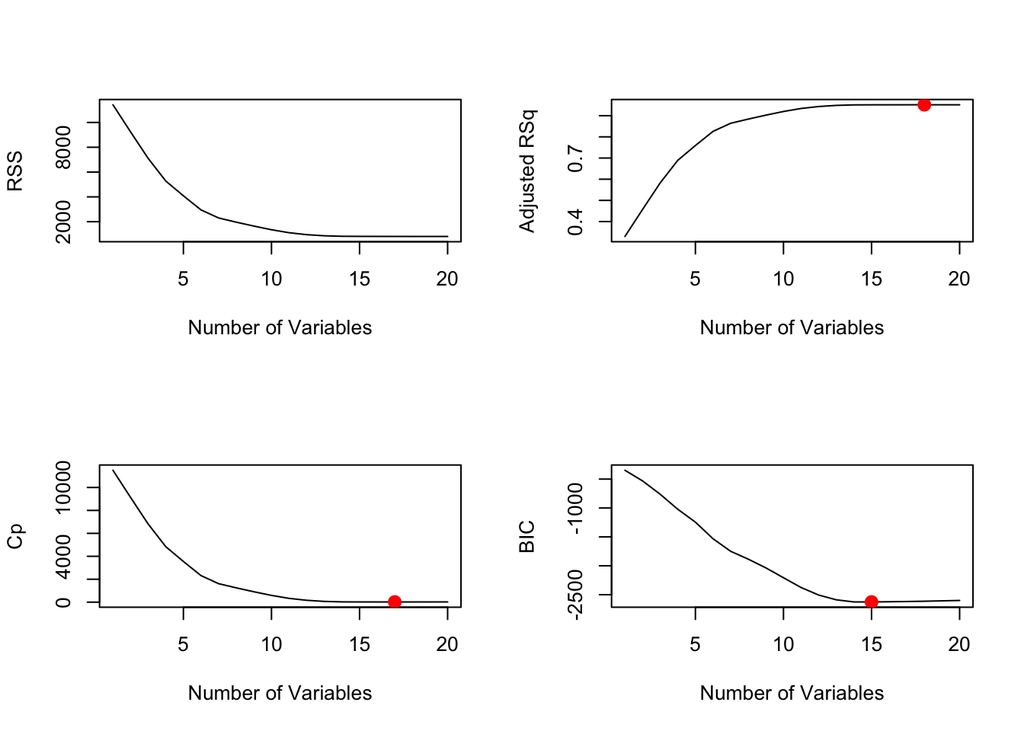

```r
maxadj2 <- which.max(reg.summary$adjr2)
par(mfrow = c(2, 2))
plot(reg.summary$rss, xlab = "Number of Variables", ylab = "RSS", type = "l")
plot(reg.summary$adjr2, xlab = "Number of Variables", ylab = "Adjusted RSq", type = "l")
points(maxadj2, reg.summary$adjr2[maxadj2], col = "red", cex = 2, pch = 20)
plot(reg.summary$cp, xlab = "Number of Variables", ylab = "Cp", type = "l")
mincp <- which.min(reg.summary$cp)
points(mincp, reg.summary$cp[mincp], col = "red", cex = 2, pch = 20)
minbic <- which.min(reg.summary$bic)
plot(reg.summary$bic, xlab = "Number of Variables", ylab = "BIC", type = "l")
points(minbic, reg.summary$bic[minbic], col = "red", cex = 2, pch = 20)
```

```r
val.errors <- rep(NA, 20)
test.mat <- model.matrix(Y ~ ., data = dataTrain)
for (i in 1:20) {
  coefi <- coef(regfit.best, id = i)
  pred <- test.mat[, names(coefi)] %*% coefi
  val.errors[i] <- mse(dataTrain$Y, pred)
}
val.errors
```

```
##  [1] 12.6937209 10.2676571  7.8887660  5.8639984  4.5419300  3.2777394
##  [7]  2.5558977  2.1809346  1.8299019  1.5025815  1.2358137  1.0607640
## [13]  0.9606575  0.9156003  0.9081244  0.9047762  0.9022007  0.9003724
## [19]  0.9002231  0.9000716
```

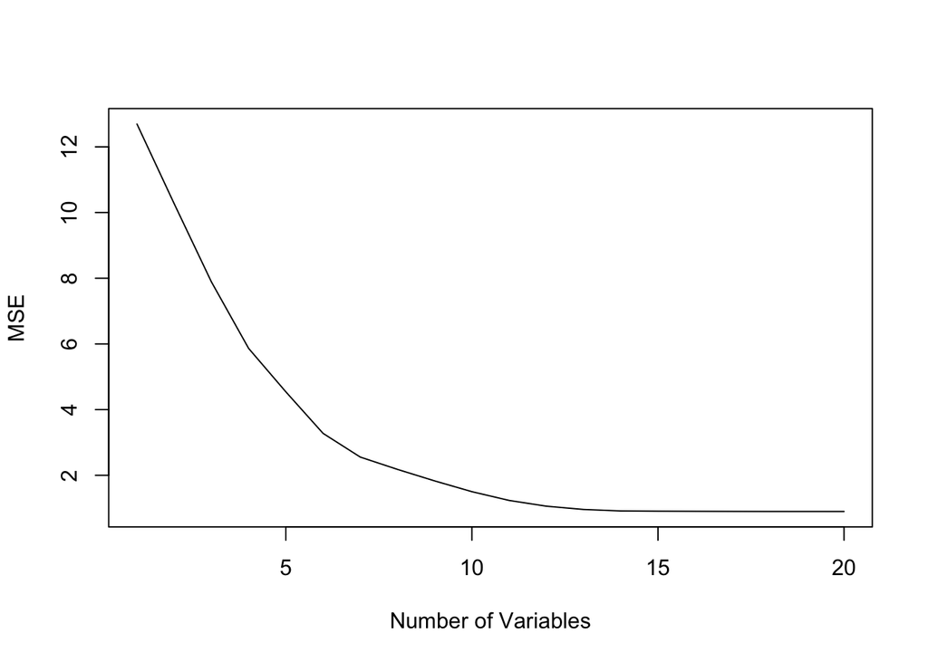

```r
par(mfrow = c(1, 1))
plot(val.errors, xlab = "Number of Variables", ylab = "MSE", type = "l")
```

```r
which.min(val.errors)
```

```
## [1] 20
```

R2 увеличивается с 0.33 при включении одной переменной до 0.95 при включении всех переменных, при этом примерно начиная с 12 переменных R2 почти не увеличивается. Рассматривая BIC стоит взять 15 переменных, $C_p$– 17, AdjustedR2– 18, MSE– 20.

4. Plot the test set MSE associated with the best model of each size:

```r
val.errors <- rep(NA, 20)
test.mat <- model.matrix(Y ~ ., data = dataTest)
for (i in 1:20) {
  coefi <- coef(regfit.best, id = i)
  pred <- test.mat[, names(coefi)] %*% coefi
  val.errors[i] <- mse(dataTest$Y, pred)
}
val.errors
```

```
##  [1] 12.8992205  9.7980549  7.6845653  4.7118708  4.3547686  3.3866077
##  [7]  2.1652834  1.5994235  1.5619454  1.4941117  1.2891076  0.9950936
## [13]  0.9322297  0.8799414  0.8836371  0.8928573  0.8838214  0.8834293
## [19]  0.8830226  0.8839208
```

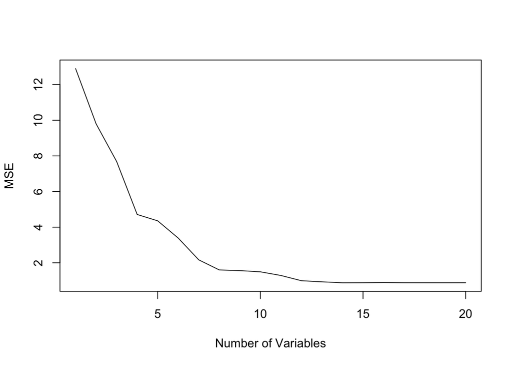

```r
plot(val.errors, xlab = "Number of Variables", ylab = "MSE", type = "l")
```

5. For which model size does the test set MSE take on its minimum value:

```r
which.min(val.errors)
```

```
## [1] 14
```

Минимальное MSE для модели из 14 признаков (пришлось менять генерацию, так как до этого минимум достигался при использовании всех 20 признаков).

6. How does the model at which the test set MSE is minimized compare to the true model used to generate the data:

```r
beta
```

```
##  [1]  0.51240790  1.17131170  1.68230849 -0.52088679  0.60560738 -0.41469046
##  [7] -0.08435169 -0.19954722  0.00000000  1.01197321  1.49715162  0.04367244
## [13]  0.03025472  0.00000000  0.00000000  1.57998423  0.30475423  0.44920250
## [19]  2.36518026  0.84248272
```

```r
coef(regfit.best, which.min(val.errors))
```

```
##  (Intercept)           X1           X2           X3           X4           X5
##  0.009850446  0.555615042  1.189021540  1.724050930 -0.540542038  0.621136942
##           X6           X8          X10          X11          X16          X17
## -0.405851088 -0.212075872  1.032427601  1.519920355  1.571404752  0.335399437
##          X18          X19          X20
##  0.508097086  2.400064003  0.844428868
```

В модель не были взяты признаки соответствующие нулевым элементам $\beta$, а также признаки 7, 12 и 13, которые также близки к нулю. Коэффициенты из модели близки к соответствующим значениям из вектора $\beta$.

5. Create a plot displaying $\sqrt{\sum_{j=1}^p(\beta_j-\hat\beta^r_j)^2}$ for a range of values of $r$, where $\hat\beta^r_j$ is the $j$-th coefficient estimate for the best model containing $r$ coefficients.

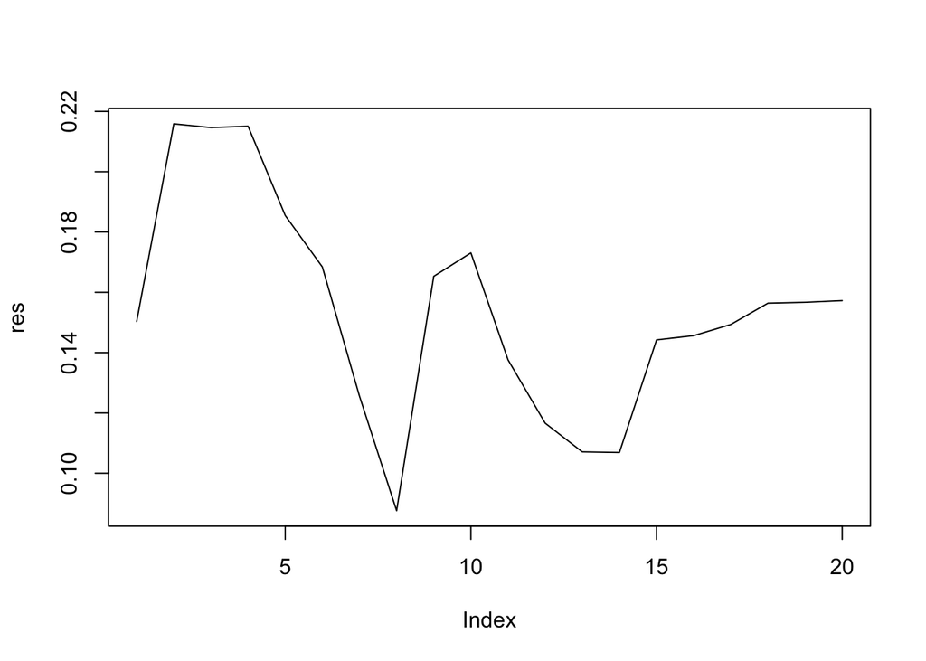

```r
res <- vector()
for (i in 1:20){
  r.best <- coef(regfit.best, i)
  t <- 0
  for (j in 2:(i+1)){
    t <- t + (r.best[j]-beta[[names(r.best)[j]]])^2
  }
  res <- append(res, sqrt(t))
}
plot(res, t = 'l')
```